# lecture 7

keerthi

2025-04-20

# 1. INTRODUCTION

# 2 . Data

```r
data = Default
str(data)
```

```
## 'data.frame':    10000 obs. of  4 variables:
##  $ default: Factor w/ 2 levels "No","Yes": 1 1 1 1 1 1 1 1 1 1 ...
##  $ student: Factor w/ 2 levels "No","Yes": 1 2 1 1 1 2 1 2 1 1 ...
##  $ balance: num  730 817 1074 529 786 ...
##  $ income : num  44362 12106 31767 35704 38463 ...
```

## 2.1 visualizing the data

### 2.1.1 Distribution of Balance

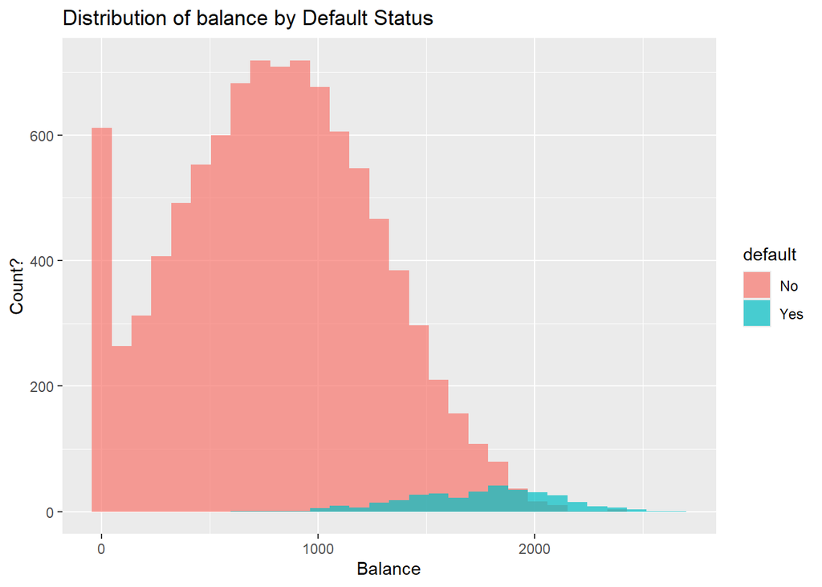

```r
ggplot(data, aes(x =balance, fill=default)) +
  geom_histogram(bins = 30, alpha = 0.7, position = 'identity' ) +
  labs(title = "Distribution of balance by Default Status",
       x = "Balance",
       y = "Count?")
```

### 2.1.2 Distribution of Income

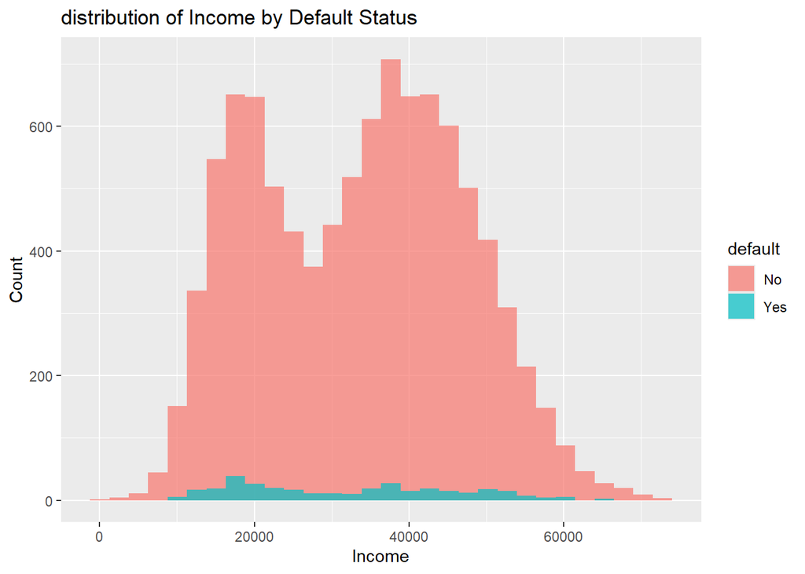

```r
ggplot(data, aes(x = income, fill = default)) +
  geom_histogram(bins = 30, alpha = 0.7, position = 'identity') +
  labs(title = "distribution of Income by Default Status",
       x = "Income",
       y = "Count")
```

[figure not shown]

```r
ggplot(data, aes(x = income, fill = student)) +
  geom_histogram(bins = 30, alpha = 0.7, position = 'identity') +
  labs(title = "distribution of Income by Default Status",
       x = "Income",
       y = "Count")
```

### 2.1.3 Student Status by Default

[figure not shown]

```r
ggplot(data, aes(x = student, fill = default)) +
  geom_bar(position ='dodge') +
  labs(title = "distribution of Income by Student Status",
       x = "Student",
       y = "Count")
```

# 4. Logistic Regression

### 4.1 Fitting the Model

```r
logit_model = glm(default ~ balance, data = data, family = binomial)
summary(logit_model)
```

```
##
## Call:
## glm(formula = default ~ balance, family = binomial, data = data)
##
## Coefficients:
##               Estimate Std. Error z value Pr(>|z|)
## (Intercept) -1.065e+01  3.612e-01  -29.49   <2e-16 ***
## balance      5.499e-03  2.204e-04   24.95   <2e-16 ***
## ---
## Signif. codes:  0 '***' 0.001 '**' 0.01 '*' 0.05 '.' 0.1 ' ' 1
##
## (Dispersion parameter for binomial family taken to be 1)
##
##     Null deviance: 2920.6  on 9999  degrees of freedom
## Residual deviance: 1596.5  on 9998  degrees of freedom
## AIC: 1600.5
##
## Number of Fisher Scoring iterations: 8
```

```r
data$predicted_prob = predict(logit_model, type = "response")
head(data)
```

```
##   default student   balance    income predicted_prob
## 1      No      No  729.5265 44361.625   0.0013056797
## 2      No     Yes  817.1804 12106.135   0.0021125949
## 3      No      No 1073.5492 31767.139   0.0085947405
## 4      No      No  529.2506 35704.494   0.0004344368
## 5      No      No  785.6559 38463.496   0.0017769574
## 6      No     Yes  919.5885  7491.559   0.0037041528
```

### 4.2 Evaluate Model Performance

```r
threshold = 0.5
data$predicted_default = ifelse(data$predicted_prob > threshold, "yes", "No")
conf_matrix = table(data$predicted_default, data$default)
conf_matrix
```

```
##
##         No  Yes
##   No  9625  233
##   yes   42  100
```

```r
accuracy = sum(diag(conf_matrix)) / sum(conf_matrix)
accuracy
```

```
## [1] 0.9725
```

# 5. Multiple Logistic Regression

## 5.1 Fitting the Model

```r
logit_mult_model = glm(default ~ balance + income * student, data=data,
family=binomial)
summary(logit_mult_model)
```

```
##
## Call:
## glm(formula = default ~ balance + income * student, family = binomial,
##     data = data)
##
## Coefficients:
##                     Estimate Std. Error z value Pr(>|z|)
## (Intercept)       -1.081e+01  5.031e-01 -21.495   <2e-16 ***
## balance            5.737e-03  2.319e-04  24.736   <2e-16 ***
## income             1.644e-06  8.633e-06   0.190    0.849
## studentYes        -9.343e-01  6.067e-01  -1.540    0.124
## income:studentYes  1.429e-05  2.772e-05   0.516    0.606
## ---
## Signif. codes:  0 '***' 0.001 '**' 0.01 '*' 0.05 '.' 0.1 ' ' 1
##
## (Dispersion parameter for binomial family taken to be 1)
##
##     Null deviance: 2920.6  on 9999  degrees of freedom
## Residual deviance: 1571.3  on 9995  degrees of freedom
## AIC: 1581.3
##
## Number of Fisher Scoring iterations: 8
```

## 5.2 Evaluating the Model

```r
data$mult_predicted_prob = predict(logit_mult_model, type = "response")
data$mult_predicted_default = ifelse(data$mult_predicted_prob > threshold, "Yes", "No")
conf_matrix_mult = table(data$mult_predicted_default, data$default)
conf_matrix_mult
```

```
##
##         No  Yes
##   No  9628  227
##   Yes   39  106
```

```r
accuracy_mult = sum(diag(conf_matrix_mult)) / sum(conf_matrix_mult)
accuracy_mult
```

```
## [1] 0.9734
```

# 6. Multinomial Logistic Regression

## 6.1 Load the Data

```r
data2 = Carseats
data2$SalesCategory = cut(data2$Sales, breaks = 3, labels = c("Low", "Medium", "High"))
```

```r
multi_model = multinom(SalesCategory ~ Price + Income +Advertising,
data = data2)
summary(multi_model)
```

```
## Call:
## multinom(formula = SalesCategory ~ Price + Income + Advertising,
##     data = data2)
##
## Coefficients:
##        (Intercept)       Price      Income Advertising
## Medium    3.645096 -0.02909122 0.004288951   0.0834958
## High      4.839031 -0.06414212 0.011164722   0.1417921
##
## Std. Errors:
##        (Intercept)       Price      Income Advertising
## Medium   0.7937487 0.006004112 0.004488935  0.02137942
## High     1.1240727 0.009264365 0.006892574  0.03025054
##
## Residual Deviance: 640.794
## AIC: 656.794
```

## 6.2 Make Predictions

```r
data2$nomial_predicted_salesCat = predict(multi_model)
head(data2)
```

```
##   Sales CompPrice Income Advertising Population Price ShelveLoc Age Education
## 1  9.50       138     73          11        276   120       Bad  42        17
## 2 11.22       111     48          16        260    83      Good  65        10
## 3 10.06       113     35          10        269    80    Medium  59        12
## 4  7.40       117    100           4        466    97    Medium  55        14
## 5  4.15       141     64           3        340   128       Bad  38        13
## 6 10.81       124    113          13        501    72       Bad  78        16
##   Urban  US SalesCategory nomial_predicted_salesCat
## 1   Yes Yes        Medium                    Medium
## 2   Yes Yes          High                    Medium
## 3   Yes Yes        Medium                    Medium
## 4   Yes Yes        Medium                    Medium
## 5   Yes  No           Low                    Medium
## 6    No Yes        Medium                      High
```

## 6.3 Evaluate Model

```r
conf_matrix_multi = table(data2$nomial_predicted_salesCat, data2$SalesCategory)
conf_matrix_multi
```

```
##
##          Low Medium High
##   Low     25     17    0
##   Medium  77    224   48
##   High     0      6    3
```

```r
accuracy_multi = sum(diag(conf_matrix_multi)) / sum(conf_matrix_multi)
accuracy_multi
```

```
## [1] 0.63
```

# Assignment Section

### Background

Diabetes is a chronic disease affecting millions of individuals worldwide. Early detection through predictive modelling can help guide prevention and treatment. in this assignment , you will use logistic regression to predict whether an individual has diabetes using basic health information.

We will use the Pima Indians Diabetes Dataset, a commonly used dataset in health informatics available from the UCI Machine Learning Repository and built into the mlbench R package.

## Simple Logistic Regression

```r
#install.packages("mlbench")
library(mlbench)
data("PimaIndiansDiabetes2")
df = PimaIndiansDiabetes2
```

### Data Exploration and Summary Figures

# Preview dataset

```r
head(df)
```

```
##   pregnant glucose pressure triceps insulin mass pedigree age diabetes
## 1        6     148       72      35      NA 33.6    0.627  50      pos
## 2        1      85       66      29      NA 26.6    0.351  31      neg
## 3        8     183       64      NA      NA 23.3    0.672  32      pos
## 4        1      89       66      23      94 28.1    0.167  21      neg
## 5        0     137       40      35     168 43.1    2.288  33      pos
## 6        5     116       74      NA      NA 25.6    0.201  30      neg
```

# view the structure of the dataset

```r
str(df)
```

```
## 'data.frame':    768 obs. of  9 variables:
##  $ pregnant: num  6 1 8 1 0 5 3 10 2 8 ...
##  $ glucose : num  148 85 183 89 137 116 78 115 197 125 ...
##  $ pressure: num  72 66 64 66 40 74 50 NA 70 96 ...
##  $ triceps : num  35 29 NA 23 35 NA 32 NA 45 NA ...
##  $ insulin : num  NA NA NA 94 168 NA 88 NA 543 NA ...
##  $ mass    : num  33.6 26.6 23.3 28.1 43.1 25.6 31 35.3 30.5 NA ...
##  $ pedigree: num  0.627 0.351 0.672 0.167 2.288 ...
##  $ age     : num  50 31 32 21 33 30 26 29 53 54 ...
##  $ diabetes: Factor w/ 2 levels "neg","pos": 2 1 2 1 2 1 2 1 2 2 ...
```

# check the dimensions

```r
dim(df)
```

```
## [1] 768   9
```

# view column names

```r
colnames(df)
```

```
## [1] "pregnant" "glucose"  "pressure" "triceps"  "insulin"  "mass"     "pedigree"
## [8] "age"      "diabetes"
```

```
# Get summary statistics for the dataset
```

```r
summary(df)
```

```
##     pregnant         glucose         pressure         triceps
##  Min.   : 0.000   Min.   : 44.0   Min.   : 24.00   Min.   : 7.00
##  1st Qu.: 1.000   1st Qu.: 99.0   1st Qu.: 64.00   1st Qu.:22.00
##  Median : 3.000   Median :117.0   Median : 72.00   Median :29.00
##  Mean   : 3.845   Mean   :121.7   Mean   : 72.41   Mean   :29.15
##  3rd Qu.: 6.000   3rd Qu.:141.0   3rd Qu.: 80.00   3rd Qu.:36.00
##  Max.   :17.000   Max.   :199.0   Max.   :122.00   Max.   :99.00
##                   NA's   :5       NA's   :35       NA's   :227
##     insulin            mass          pedigree           age        diabetes
##  Min.   : 14.00   Min.   :18.20   Min.   :0.0780   Min.   :21.00   neg:500
##  1st Qu.: 76.25   1st Qu.:27.50   1st Qu.:0.2437   1st Qu.:24.00   pos:268
##  Median :125.00   Median :32.30   Median :0.3725   Median :29.00
##  Mean   :155.55   Mean   :32.46   Mean   :0.4719   Mean   :33.24
##  3rd Qu.:190.00   3rd Qu.:36.60   3rd Qu.:0.6262   3rd Qu.:41.00
##  Max.   :846.00   Max.   :67.10   Max.   :2.4200   Max.   :81.00
##  NA's   :374      NA's   :11
```

## **Glucose Level Distribution**

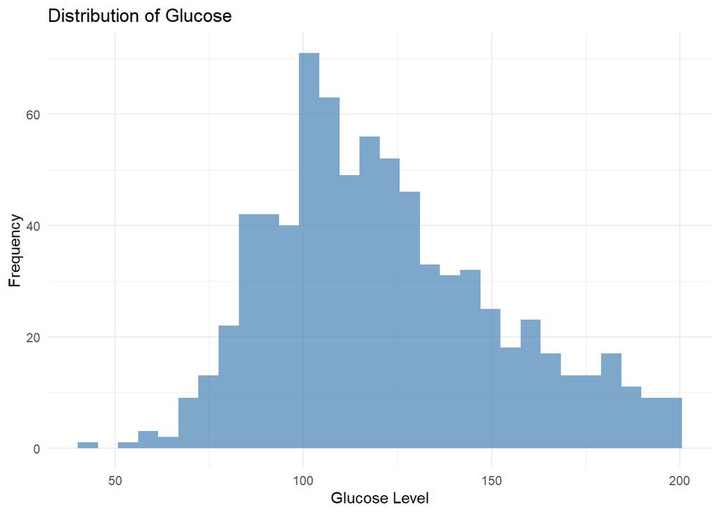

```r
library(ggplot2)

ggplot(df, aes(x = glucose)) +
  geom_histogram(bins = 30, fill = "steelblue", alpha = 0.7) +
  labs(title = "Distribution of Glucose", x = "Glucose Level", y = "Frequency") +
  theme_minimal()
```

## **Body Mass Index (BMI) Distribution**

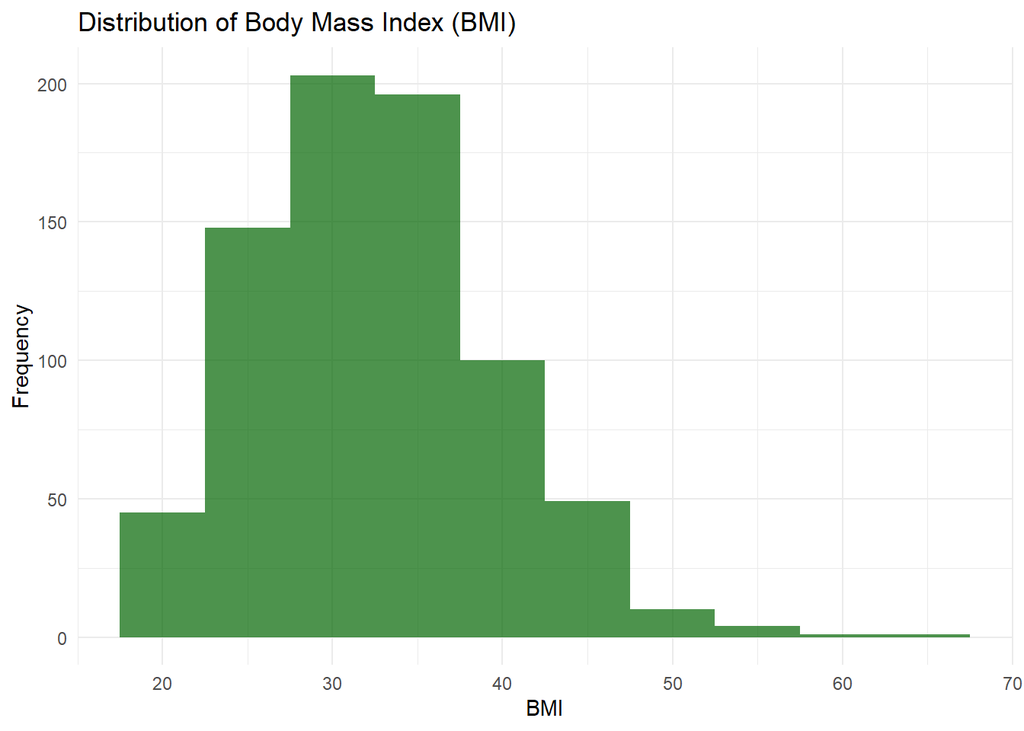

```r
ggplot(df, aes(x = mass)) +
  geom_histogram(binwidth = 5, fill = "darkgreen", alpha = 0.7) +
  labs(title = "Distribution of Body Mass Index (BMI)", x = "BMI", y = "Frequency") +
  theme_minimal()
```

The histogram shows the distribution of Body Mass Index (BMI) among individuals in the dataset. Most BMI values fall between 25 and 40, with a peak around 30–35, indicating that a large portion of participants are in the overweight to obese range. There are very few instances of extremely low or high BMI values. This variable could be a strong predictor of diabetes, given the established link between higher BMI and diabetes risk.

## **Age Distribution**

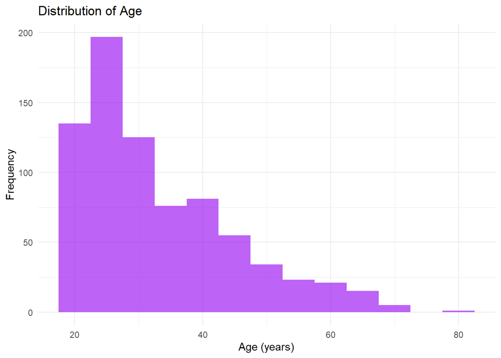

```r
ggplot(df, aes(x = age)) +
  geom_histogram(binwidth = 5, fill = "purple", alpha = 0.7) +
  labs(title = "Distribution of Age", x = "Age (years)", y = "Frequency") +
  theme_minimal()
```

The histogram of age shows a right-skewed distribution, with most individuals in the dataset being between 20 and 40 years old. The number of participants gradually decreases with increasing age, indicating fewer older individuals in the study. Age may play an important role in predicting diabetes, particularly given the increased risk with advancing age.

## **Pregnancies Distribution**

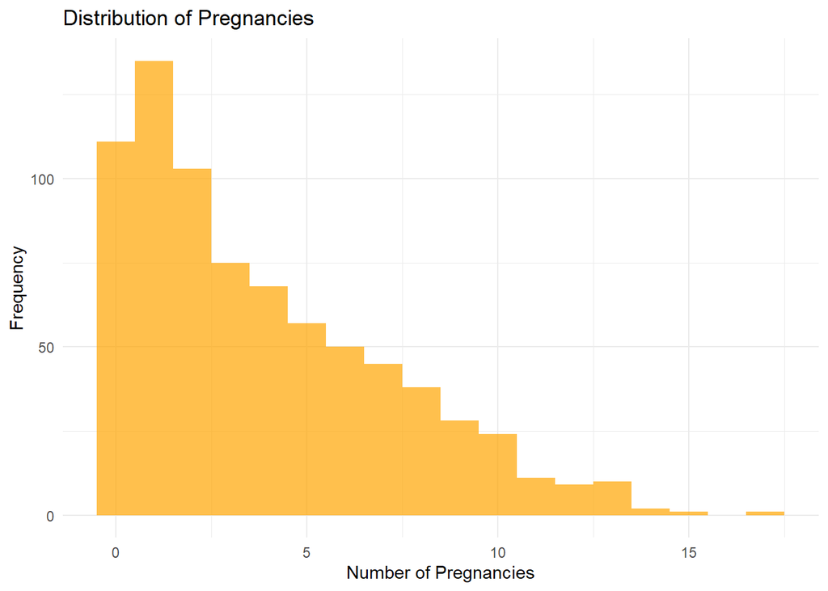

```r
ggplot(df, aes(x = pregnant)) +
  geom_histogram(binwidth = 1, fill = "orange", alpha = 0.7) +
  labs(title = "Distribution of Pregnancies", x = "Number of Pregnancies", y = "Frequency") +
  theme_minimal()
```

The histogram for number of pregnancies is right-skewed, with most individuals having fewer than 5 pregnancies. A smaller proportion of the population experienced higher pregnancy counts. This variable may reflect reproductive health history, which can be associated with diabetes risk.

## **Diabetes Outcome Counts**

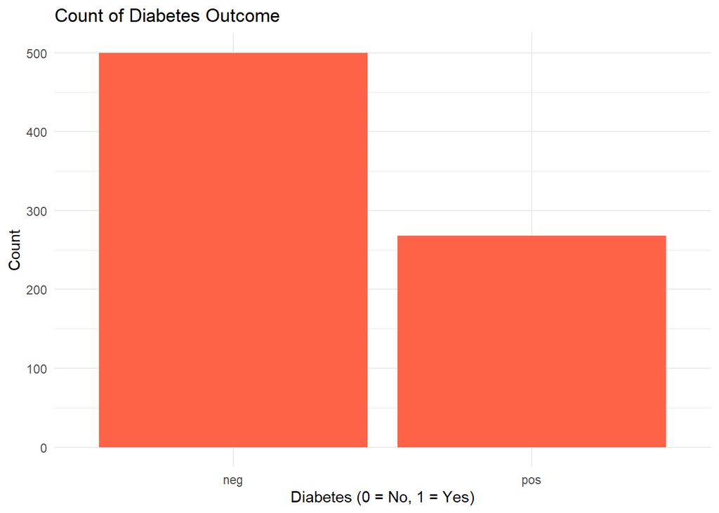

```r
ggplot(df, aes(x = diabetes)) +
  geom_bar(fill = "tomato") +
  labs(title = "Count of Diabetes Outcome", x = "Diabetes (0 = No, 1 = Yes)", y = "Count") +
  theme_minimal()
```

### Fit a Simple Logistic Regression Model (Train & Test Split)

#load required packages

```r
library(mlbench)
library(dplyr)
```

##

##

##

```r
library(caret)
```

## Loading required package: lattice

```r
# Load data
data("PimaIndiansDiabetes")
df <- PimaIndiansDiabetes
```

```r
# Split data into training (70%) and testing (30%)
set.seed(123)
split <- createDataPartition(df$diabetes, p = 0.7, list = FALSE)
train_data <- df[split, ]
test_data <- df[-split, ]
```

```r
# Fit logistic regression model using glucose as predictor
logit_model <- glm(diabetes ~ glucose, data = train_data, family = "binomial")
```

```r
# Summary of the model
summary(logit_model)
```

```
##
## Call:
## glm(formula = diabetes ~ glucose, family = "binomial", data = train_data)
##
## Coefficients:
##              Estimate Std. Error z value Pr(>|z|)
## (Intercept) -5.080427   0.493386 -10.297   <2e-16 ***
## glucose      0.035965   0.003841   9.363   <2e-16 ***
## ---
## Signif. codes:  0 '***' 0.001 '**' 0.01 '*' 0.05 '.' 0.1 ' ' 1
##
## (Dispersion parameter for binomial family taken to be 1)
##
##     Null deviance: 696.28  on 537  degrees of freedom
## Residual deviance: 580.34  on 536  degrees of freedom
## AIC: 584.34
##
## Number of Fisher Scoring iterations: 4
```

### Interpret Coefficients & Apply the Model for Prediction on the test Data

The logistic regression output shows that glucose is a statistically significant predictor of diabetes status. The coefficient for glucose is 0.036, which indicates that for each one-unit increase in glucose level, the log-odds of having diabetes increases by approximately 0.036. This translates to an odds ratio of about 1.037, meaning there is a 3.7% increase in the odds of having diabetes for each additional unit of glucose. The p-value for glucose is less than 0.001, confirming strong statistical significance. Additionally, the model’s residual deviance decreased from 696.28 (null model) to 580.34, suggesting that glucose explains a meaningful amount of variation in diabetes outcomes.

```r
# Predict probabilities on test data
test_probs <- predict(logit_model, newdata = test_data, type = "response")
```

```r
# Convert probabilities to predicted classes (threshold = 0.5)
test_pred <- ifelse(test_probs > 0.5, "pos", "neg")
test_pred <- factor(test_pred, levels = c("neg", "pos"))
```

```r
# Confusion matrix to evaluate accuracy
confusionMatrix(test_pred, test_data$diabetes)
```

```
## Confusion Matrix and Statistics
##
##           Reference
## Prediction neg pos
##        neg 129  39
##        pos  21  41
##
##                Accuracy : 0.7391
##                  95% CI : (0.6773, 0.7946)
##     No Information Rate : 0.6522
##     P-Value [Acc > NIR] : 0.002949
##
##                   Kappa : 0.3931
##
##  Mcnemar's Test P-Value : 0.028186
##
##             Sensitivity : 0.8600
##             Specificity : 0.5125
##          Pos Pred Value : 0.7679
##          Neg Pred Value : 0.6613
##              Prevalence : 0.6522
##          Detection Rate : 0.5609
##    Detection Prevalence : 0.7304
##       Balanced Accuracy : 0.6863
##
##        'Positive' Class : neg
##
```

#### **Fit a Multiple Logistic Regression Model (Train & Test Split)**

```r
# Fit multiple logistic regression model
multi_logit_model <- glm(diabetes ~ glucose + age + mass + pregnant,
                         data = train_data, family = "binomial")
```

```r
# View summary
summary(multi_logit_model)
```

```
##
## Call:
## glm(formula = diabetes ~ glucose + age + mass + pregnant, family = "binomial",
##     data = train_data)
##
## Coefficients:
##              Estimate Std. Error z value Pr(>|z|)
## (Intercept) -8.422351   0.806604 -10.442  < 2e-16 ***
## glucose      0.031049   0.003936   7.888 3.08e-15 ***
## age          0.023320   0.010853   2.149   0.0317 *
## mass         0.086208   0.016369   5.267 1.39e-07 ***
## pregnant     0.071427   0.037236   1.918   0.0551 .
## ---
## Signif. codes:  0 '***' 0.001 '**' 0.01 '*' 0.05 '.' 0.1 ' ' 1
##
## (Dispersion parameter for binomial family taken to be 1)
##
##     Null deviance: 696.28  on 537  degrees of freedom
## Residual deviance: 531.64  on 533  degrees of freedom
## AIC: 541.64
##
## Number of Fisher Scoring iterations: 5
```

#### **Interpret Coefficients & Apply the Model for Prediction on Test Data**

The multiple logistic regression model includes glucose, age, BMI (mass), and number of pregnancies as predictors of diabetes. All four predictors are positively associated with the odds of having diabetes. The glucose coefficient (0.031) is highly significant (p < 0.001), indicating that for every one-unit increase in glucose, the odds of diabetes increase by approximately 3.1% (exp(0.031) ≈ 1.031). Similarly, BMI (mass) has a strong positive effect, with each one-unit increase associated with an 8.9% increase in odds (exp(0.086) ≈ 1.089). Age is also statistically significant (p = 0.031), with each additional year increasing the odds by around 2.4%. The number of pregnancies has a smaller and borderline-significant effect (p = 0.055), suggesting a possible positive trend. Overall, these results confirm that glucose, BMI, and age are important independent predictors of diabetes, while the effect of pregnancy count may be weaker.

```r
# Predict probabilities on test data
test_probs_multi <- predict(multi_logit_model, newdata = test_data, type = "response")
```

```r
# Convert probabilities to predicted class labels (threshold = 0.5)
test_pred_multi <- ifelse(test_probs_multi > 0.5, "pos", "neg")
test_pred_multi <- factor(test_pred_multi, levels = c("neg", "pos"))
```

```r
# Evaluate with confusion matrix
confusionMatrix(test_pred_multi, test_data$diabetes)
```

```
## Confusion Matrix and Statistics
##
##           Reference
## Prediction neg pos
##        neg 131  33
##        pos  19  47
##
##                Accuracy : 0.7739
##                  95% CI : (0.7143, 0.8263)
##     No Information Rate : 0.6522
##     P-Value [Acc > NIR] : 4.208e-05
##
##                   Kappa : 0.4805
##
##  Mcnemar's Test P-Value : 0.07142
##
##             Sensitivity : 0.8733
##             Specificity : 0.5875
##          Pos Pred Value : 0.7988
##          Neg Pred Value : 0.7121
##              Prevalence : 0.6522
##          Detection Rate : 0.5696
##    Detection Prevalence : 0.7130
##       Balanced Accuracy : 0.7304
##
##        'Positive' Class : neg
##
```

When applied to the test data, the multiple logistic regression model achieved an accuracy of 77.4%, an improvement over the simple model using only glucose. The sensitivity (true negative rate) remained high at 87.3%, meaning the model correctly identified most non-diabetic individuals. Importantly, specificity improved to 58.8%, indicating a better ability to detect actual diabetic cases compared to the simple model. The balanced accuracy rose to 73.0%, and the Kappa value increased to 0.48, suggesting stronger agreement between predictions and true outcomes. These results show that adding predictors like BMI, age, and number of pregnancies meaningfully improved the model’s predictive power and its ability to generalize to new data.

## **K-Nearest Neighbors Classification**

K-Nearest Neighbors (KNN) is a simple, flexible algorithm that makes predictions based on the majority class of the closest data points.

Use the `caret` and `class` libraries with the `knn()` function. See our in-class lab for a worked example.

#### **Prepare the Data**

```r
# Load libraries
library(class)
library(caret)
library(dplyr)
```

```r
# Load libraries
library(class)
library(caret)
library(dplyr)

# Normalize numeric predictors for KNN
normalize <- function(x) {
  return((x - min(x)) / (max(x) - min(x)))
}

# Select relevant predictors
knn_df <- df %>%
  select(glucose, age, mass, pregnant, diabetes) %>%
  mutate(across(-diabetes, normalize))

# Train-test split
set.seed(123)
split <- createDataPartition(knn_df$diabetes, p = 0.7, list = FALSE)
train_knn <- knn_df[split, ]
test_knn <- knn_df[-split, ]

# Separate predictors and labels
train_x <- train_knn %>% select(-diabetes)
test_x <- test_knn %>% select(-diabetes)
train_y <- train_knn$diabetes
test_y <- test_knn$diabetes
```

#### **Fit a KNN Classifier Model (Train & Test Split)**

```r
# Fit KNN model
knn_pred <- knn(train = train_x, test = test_x, cl = train_y, k = 5)

# Evaluate performance
confusionMatrix(knn_pred, test_y)
```

```
## Confusion Matrix and Statistics
##
##           Reference
## Prediction neg pos
##        neg 125  30
##        pos  25  50
##
##                Accuracy : 0.7609
##                  95% CI : (0.7004, 0.8145)
##     No Information Rate : 0.6522
##     P-Value [Acc > NIR] : 0.000245
##
##                   Kappa : 0.4651
##
##  Mcnemar's Test P-Value : 0.589639
##
##             Sensitivity : 0.8333
##             Specificity : 0.6250
##          Pos Pred Value : 0.8065
##          Neg Pred Value : 0.6667
##              Prevalence : 0.6522
##          Detection Rate : 0.5435
##    Detection Prevalence : 0.6739
##       Balanced Accuracy : 0.7292
##
##        'Positive' Class : neg
##
```

#### **Interpret & Apply to Test Data**

he K-Nearest Neighbors (KNN) model with k=5 achieved an accuracy of 76.1% on the test data, which is comparable to the multiple logistic regression model. The sensitivity was 83.3%, indicating strong performance in correctly identifying non-diabetic individuals. The specificity was 62.5%, which is slightly better than the logistic models, suggesting the KNN model also did a decent job identifying diabetic cases. The balanced accuracy of 72.9% and Kappa of 0.465 reflect moderate agreement and solid classification ability.

## **Model Comparison and Discussion**

Overall, multiple logistic regression appears to be the strongest model for this dataset, balancing accuracy, interpretability, and predictive strength. KNN, while flexible and intuitive, might benefit from further tuning (e.g., trying different k values) or additional preprocessing steps like feature selection or PCA.